# Calculating Drug Synergy Combinations with Replicates

Kieran Redpath

21 February, 2024

## Instructions

- You can run code from a .Rmd document using “Ctrl + Enter” (“Cmd + Return” on mac) on the line or a highlighted block of text. Click the arrow in the top right corner of a chunk to run the entire chunk.
- Ensure all packages are correctly installed (see “Required packages”).
- Substitute the default values under the heading “Input” with your desired values.
- Click the “Knit” button at the top of your RStudio window.

### Required packages

- Only run this chunk of code the first time you use synergyfinder on your computer, but first make sure you delete a single # from the start of each line.
- By default this code won’t be included in the output document.

### Load packages and data

```r
# Load packages
library(dplyr)
library(ggplot2)
library(gridExtra)
library(openxlsx)
library(synergyfinder)
```

## Input

```r
# Load combination data for any number of correctly indexed drug combinations (see the template file for what this should look like).
# replace filename with a .xlsx file containing your data in the right format
synergy.frame <- read.xlsx("SynergyFinderTemplate.xlsx")
synergy.frame <- na.omit(synergy.frame)

# Define which type of synergy score you want to use ("HSA", "Loewe", "Bliss", or "ZIP")
synergy.type = "Loewe"

# Define if your data is expressed as "viability" or "inhibition". Either way it should be as a percentage, not a decimal (i.e. out of 100, not 1)
data.type = "inhibition"
```

### Plot dose response curves

- Also saves these as .png’s

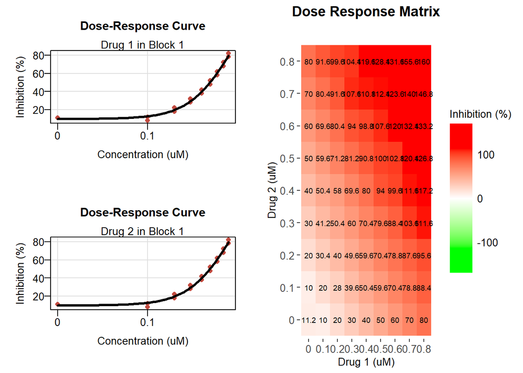

```
## $`1`
##
## $`2`
```

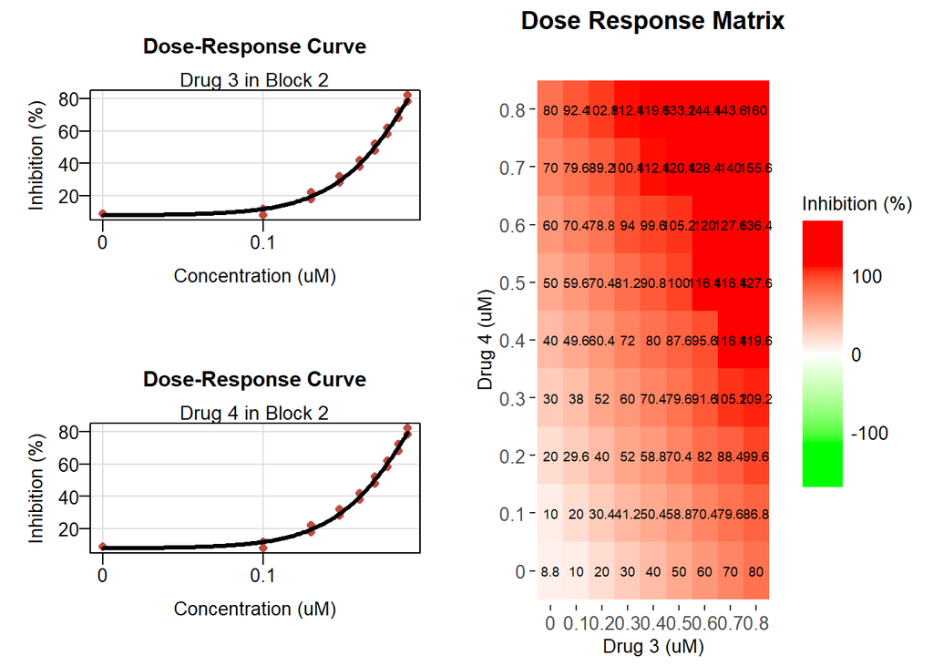

```r
# Plots curves within RStudio and the generated markdown document, but also saves a png in the current working directory
PlotDoseResponse(dose.response.mat, block_ids = dose.response.mat[["drug_pairs"]][["block_id"]], save_file = TRUE,  summary_statistic = NULL, file_type = "png")
```

### Calculate and visualise synergy scores across the inferred dose-response matrix

- Also saves these as .png’s

```r
# Calculate synergy scores
synergy.score <- CalculateSynergy(data = dose.response.mat,
                                  method = synergy.type,
                                  iteration = 100)
```

```
## Calculating synergy score(s) for block 1...
```

```
## Calculating synergy score(s) for block 2...
```

```
## $`1`
```

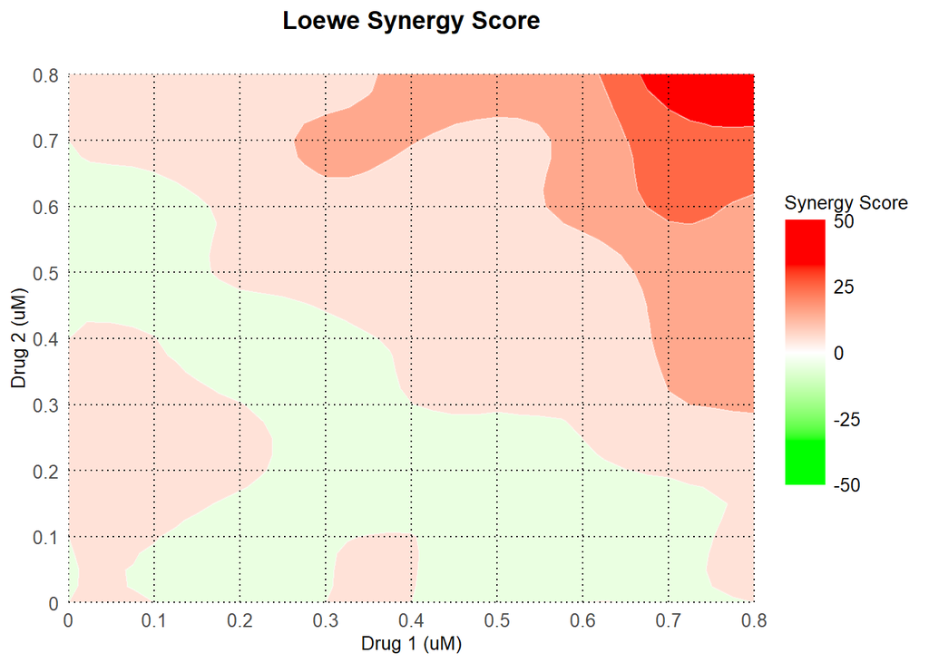

```
##
## $`2`
```

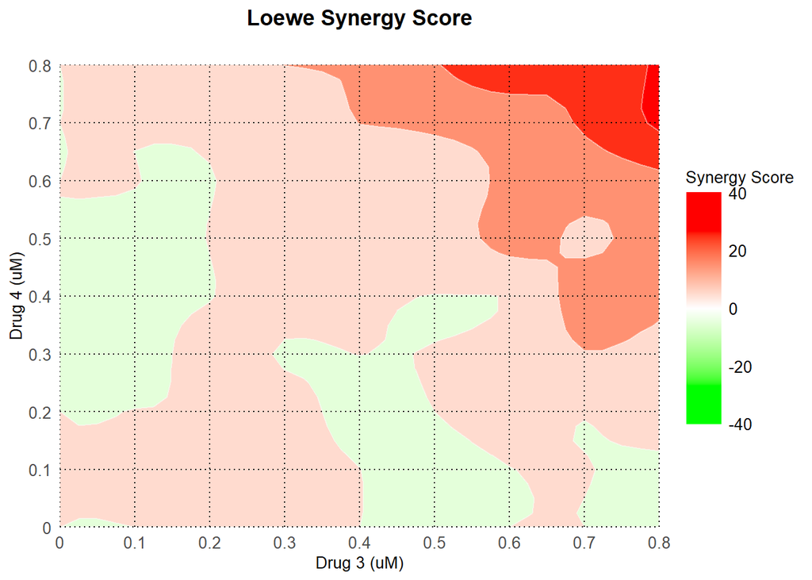

```r
# Visualise synergy scores, providing an average value and a visual indication of where synergy is high and low
# Plots scores within RStudio and the generated markdown document, but also saves a png in the current working directory
PlotSynergy(synergy.score, type = "2D", method = "Loewe", block_ids = dose.response.mat[["drug_pairs"]][["block_id"]], summary_statistic = NULL, save_file = TRUE, file_type = "png")
```

### Extract data

- This chunk of code extracts useful values from the data for visualization and plotting, for only the tested concentrations of each drug
- Data for each combo is saved in a different element of the list “synergy.response.data”
- By default the code won’t be included in the output document because it’s very long and complicated

### Save Data

- This chunk of code saves excel files of the output for each drug combination
- I don’t yet have a good way to plot this data, but it’s there for you to do what you want with it

```r
for(y in 1:length(synergy.response.data)){
  write.xlsx(synergy.response.data[[y]], file = paste0(names(synergy.response.data[y]), ".xlsx"), rowNames = T)
}
# Clean up environment
rm("y")
```